# Plot axes/scales

⌂ Contents 📁 Materials ↓ Practice ← Plots/ggplot2 Plot panels/facets/size →

In `ggplot2` the scales describe how to map your data to point colors, shapes, …  
Majority of commands to modify scales start with `scale_` followed by the name of the aesthetics which you want to describe: `scale_x_`, `scale_color_`, …

➡️Go to [RStudio Cheatsheets/Data Visualization Cheatsheet/Panel Scales](https://rstudio.com/resources/cheatsheets/) to find short summary of commands for scales.

## Location scales

These examples assume that a continuous variable is used for the **location scales**: `x` (horizontal) or `y` (vertical).

Try the following code to change the **label** of the vertical axis:

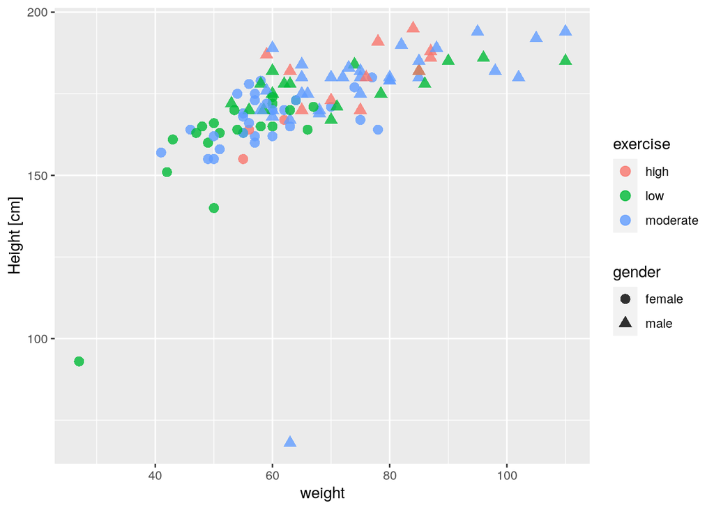

```r
ggplot( pulse ) +
  aes( x = weight, y = height, color = exercise, shape = gender ) +
  geom_point( size = 3, alpha = 0.8 ) +
  scale_y_continuous( name = "Height [cm]" )
```

Now, add an extra argument `limits` to only show points with `height` in a certain range:

```
Warning: Removed 2 rows containing missing values (geom_point).
```

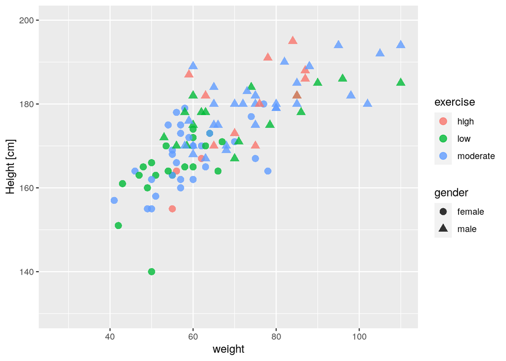

```r
ggplot( pulse ) +
  aes( x = weight, y = height, color = exercise, shape = gender ) +
  geom_point( size = 3, alpha = 0.8 ) +
  scale_y_continuous(
    name = "Height [cm]",
    limits = c( 130, 200 )
  )
```

You might see a **warning**: the current version of the `ggplot2` library seems to have a bug.  
Indeed, some points are filtered out by the `limit` argument but this is intentional and should not be reported as a warning.  
You may **disable chunk warnings** by adding an option to the chunk header:

````
```{r warning=FALSE}
ggplot( ... ) + ...
```
````

Try the extra argument `breaks` to put ticks at provided positions:

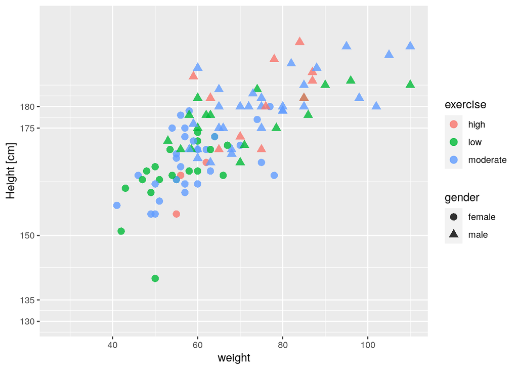

```r
ggplot( pulse ) +
  aes( x = weight, y = height, color = exercise, shape = gender ) +
  geom_point( size = 3, alpha = 0.8 ) +
  scale_y_continuous(
    name = "Height [cm]",
    limits = c( 130, 200 ),
    breaks = c( 130, 135, 150, 175, 180 )
  )
```

## Color scale (continuous)

These examples assume that a continuous variable is used for `color`.

In general we advise to use the [**Viridis color scales**](https://cran.r-project.org/web/packages/viridis/vignettes/intro-to-viridis.html) (citing: *“The viridis scales provide colour maps that are perceptually uniform in both colour and black-and-white. They are also designed to be perceived by viewers with common forms of colour blindness.”*).

Try first the following code.  
Then add `option = "A"` argument to `scale_color_viridis_c()`.  
Values from `"A"` to `"E"` provide different color mappings.

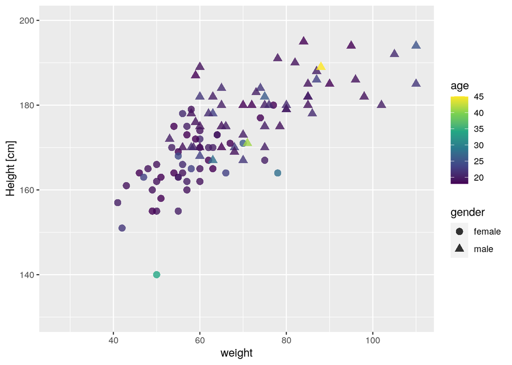

```r
ggplot( pulse ) +
  aes( x = weight, y = height, color = age, shape = gender ) +
  geom_point( size = 3, alpha = 0.8 ) +
  scale_y_continuous( name = "Height [cm]", limits = c( 130, 200 ) ) +
  scale_color_viridis_c()
```

It is also possible to have a continuous transition between two manually given colors.  
Try `low` and `high` arguments of `scale_color_continuous`:

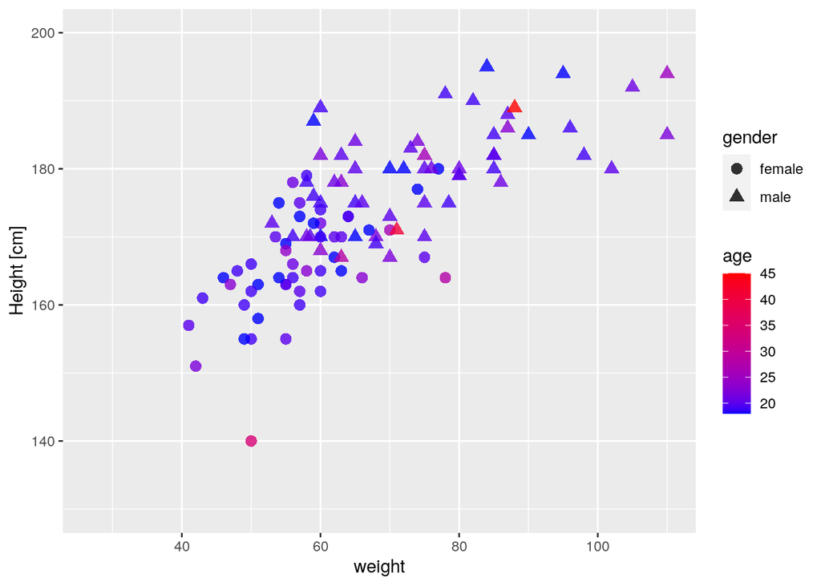

```r
ggplot( pulse ) +
  aes( x = weight, y = height, color = age, shape = gender ) +
  geom_point( size = 3, alpha = 0.8 ) +
  scale_y_continuous( name = "Height [cm]", limits = c( 130, 200 ) ) +
  scale_color_continuous( low = "blue", high = "red" )
```

Or try `scale_color_gradientn` to have continuous mapping through multiple colors:

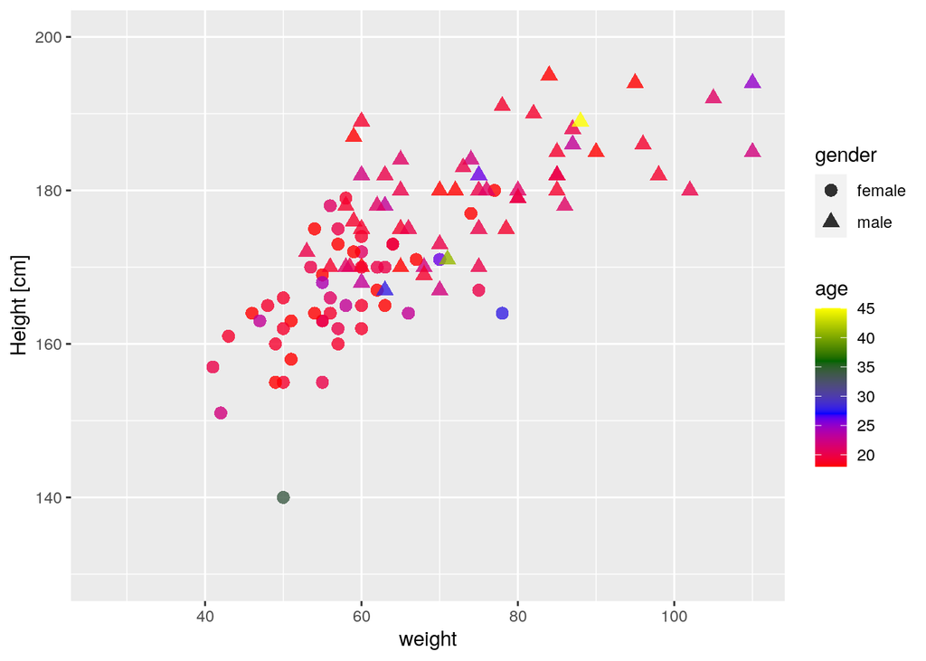

```r
ggplot( pulse ) +
  aes( x = weight, y = height, color = age, shape = gender ) +
  geom_point( size = 3, alpha = 0.8 ) +
  scale_y_continuous( name = "Height [cm]", limits = c( 130, 200 ) ) +
  scale_color_gradientn( colors = c( "red", "blue", "darkgreen", "yellow" ) )
```

## Color scale (categorical)

These examples assume that a categorical variable is used for `color`.

Also for categorical (discrete) variables the [Viridis color scheme](https://cran.r-project.org/web/packages/viridis/vignettes/intro-to-viridis.html) is advisable.  
Try the code below.  
Change the argument `option` of `scale_color_viridis_d` for different color mappings.

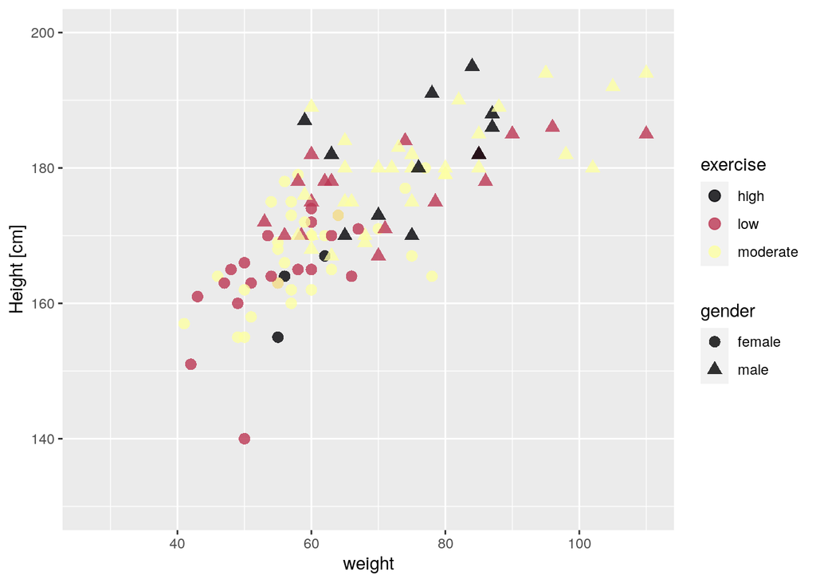

```r
ggplot( pulse ) +
  aes( x = weight, y = height, color = exercise, shape = gender ) +
  geom_point( size = 3, alpha = 0.8 ) +
  scale_y_continuous( name = "Height [cm]", limits = c( 130, 200 ) ) +
  scale_color_viridis_d( option = "B" )
```

Another possibility is to use `scale_color_manual`, which declares that the color variable is categorical and that you want to manually declare a color for each category with the `values` argument:

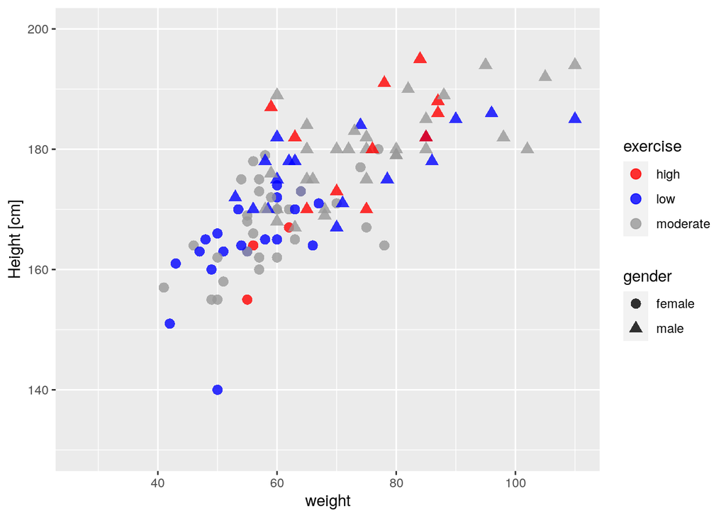

```r
ggplot( pulse ) +
  aes( x = weight, y = height, color = exercise, shape = gender ) +
  geom_point( size = 3, alpha = 0.8 ) +
  scale_y_continuous( name = "Height [cm]", limits = c( 130, 200 ) ) +
  scale_color_manual( values = c( "high" = "red", "moderate" = "gray60", "low" = "blue" ) )
```

Below observe how to use `\n` symbol to enforce multiple lines of text in the title of the color legend:

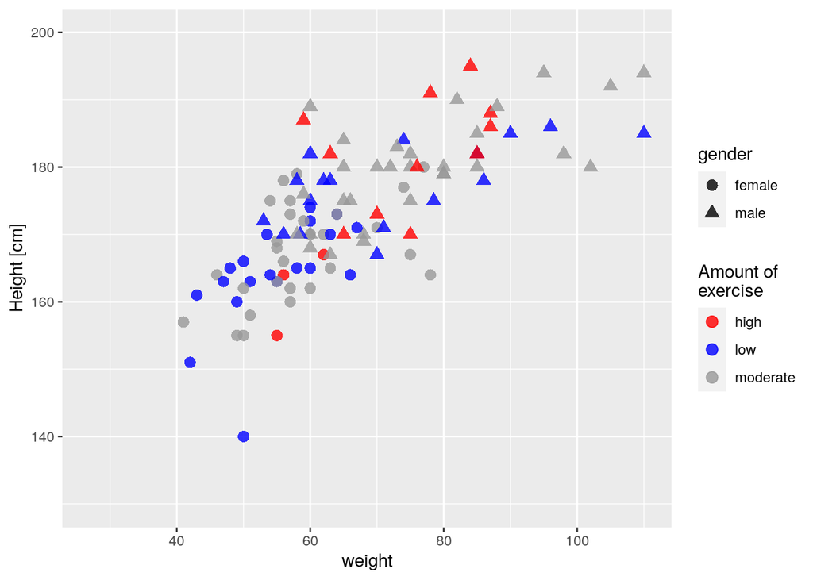

```r
ggplot( pulse ) +
  aes( x = weight, y = height, color = exercise, shape = gender ) +
  geom_point( size = 3, alpha = 0.8 ) +
  scale_y_continuous( name = "Height [cm]", limits = c( 130, 200 ) ) +
  scale_color_manual(
    values = c( "high" = "red", "moderate" = "gray60", "low" = "blue" ),
    name = "Amount of\nexercise"
  )
```

Finally, try the `breaks` argument to enforce the order of values in the legend:

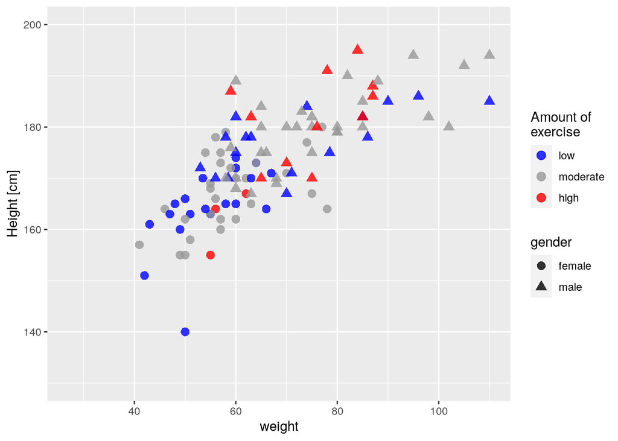

```r
ggplot( pulse ) +
  aes( x = weight, y = height, color = exercise, shape = gender ) +
  geom_point( size = 3, alpha = 0.8 ) +
  scale_y_continuous( name = "Height [cm]", limits = c( 130, 200 ) ) +
  scale_color_manual(
    values = c( "high" = "red", "moderate" = "gray60", "low" = "blue" ),
    name = "Amount of\nexercise",
    breaks = c( "low", "moderate", "high" )
  )
```

## Shape scale (categorical)

`shape` must represent a categorical variable.

Add `scale_shape_manual` to the previous example to manually declare which shapes to use for `female` and `male`:

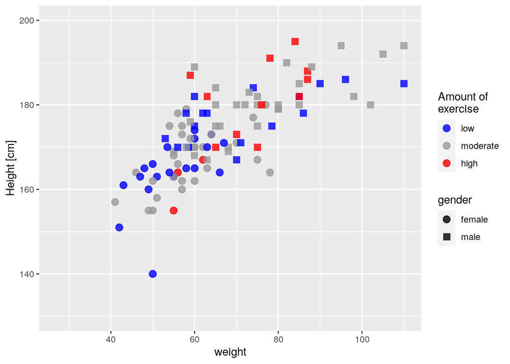

```r
ggplot( pulse ) +
  aes( x = weight, y = height, color = exercise, shape = gender ) +
  geom_point( size = 3, alpha = 0.8 ) +
  scale_y_continuous( name = "Height [cm]", limits = c( 130, 200 ) ) +
  scale_color_manual(
    values = c( "high" = "red", "moderate" = "gray60", "low" = "blue" ),
    name = "Amount of\nexercise",
    breaks = c( "low", "moderate", "high" )
  ) +
  scale_shape_manual( values = c( "male" = 15, "female" = 19 ) )
```

⌂ Contents 📁 Materials ↓ Practice ← Plots/ggplot2 Plot panels/facets/size →